# Coursework Report

*N* removed NAs: 3

*N* removed typo: 1

*N* removed <18: 18

*N* total clean: 128

| Group | *N* | *M*<sub>age</sub> | *M*<sub>rating</sub> |
| --- | --- | --- | --- |
| Control | 65 | 21.1 | 5.42 |
| Experim | 63 | 21.5 | 5.98 |

**Main analysis results**

*t*(126) = -3.89, *p* < .001

[interactive chart not shown]

[figure not shown]

[interactive chart not shown]

# Coursework Report

Analysing Data, Spring 2020

# Methods

## Design

### Hypothesis

Woman find man more attractive when red represented with man together.

### Independed variable

Colour red or white: This is a factor affecting the dependent variable. This variable is created by changing the colour of the background of the picture shown to the participants. Therefore, the operationalised independent variable is the colour of the background.

### Depended variable

Attractiveness: This variable is measured by a scale from 1(least attractive) to 9(most attractive). Therefore, this is a rating and the operationalised dependent variable is the number given to the photo by the participant.

### Operationalised hypothesis

Woman will give higher scores to men if their picture is showed with a red background. T test is going to be done for this experiment.

# Results

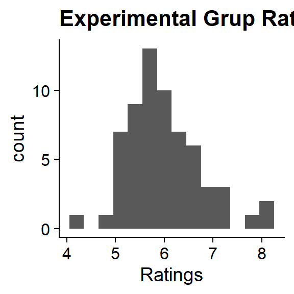

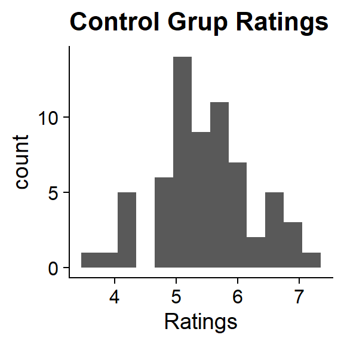

## Two sample t-test

Data: vector_experimental_means and vector_control_means

Alternative hypothesis: True difference in means is not equal to 0

95 percent confidence interval:

0.254 0.812

Sample estimates:

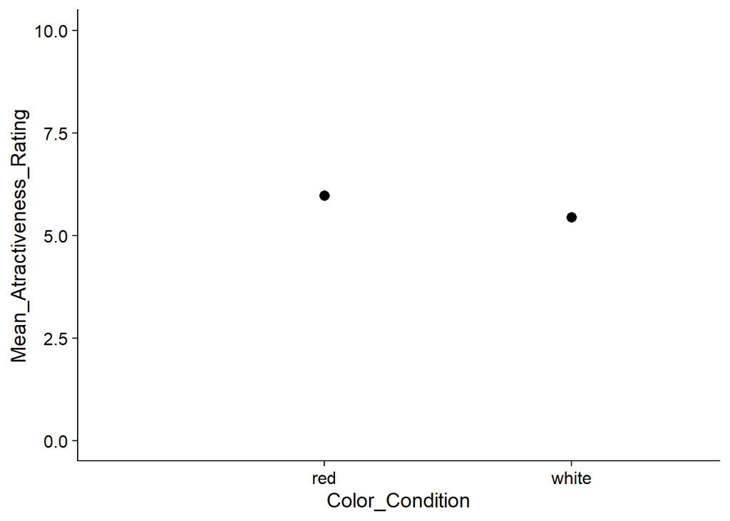

# Discussion

The results of the current study demonstrate that women find men more attractive when they are associated with the colour red. It is found that the pattern of the results supports the original study conducted by Elliot et al. (2010) in which red was shown to increase attractiveness. Since the results are significantly similar with the original study, the findings of the original study become more reliable. The original study shows that red has an effect on women’s perception on male attractiveness. By replicating this experiment in similar but different populations and finding similar pattern of results, we could now argue that the red-attractiveness effect is likely to be real. The replication of original study done by Elliot and Maier (2013) compared red with grey. The results concluded that woman find men more attractive when the subject is associated with red rather than grey. However, the difference between these two groups was not statistically significant since the values were t=1.51, p=.13,d=0.25 .This insignificance resulted in the finding of the study being ambiguous. Although, the results have a similar pattern with the original study, the insignificance supports that this effect might not be real. Another replication conducted by Hesslinger et al. (2015) examined a larger size of participants. Although the procedure was similar, the results, again, showed no significance. The small difference between means of red and white condition was not statistically significant. (condition red: M = 5.71, SD = 1.70; condition white: M = 5.39, SD = 1.53). Additionally, in their second experiment which is an extended and complex model of the original study, it was found that there was a significant difference in attractiveness only between man in casual and formal style but, not between red and white background. The first experiment conducted by Peperkoorn et al. (2016) contradicts with the results of current study since it was found out that white has an increasing effect on attractiveness rather than red. However, the difference from the current study was that woman were rated instead of men. The researchers also replicated the first study with a second experiment, by changing the population. It was found that there was no significant difference between red, white and black and also that colour was the least significant factor when men rated woman for their attractiveness (M facial expression=5.16, M clothing=4.05, M colour=2.88) Overall, the replications of the original study, except current study, don’t support the red effect and therefore disapprove of the original study. This means that the results of these studies don’t also support the current study. The main strength of our study is the fact that we have eliminated some participants, such as the ones who don’t fit in our age target and the ones whose age is not available. Thus, we eliminated the chance of finding inaccurate results due to using different age group. However, this also reduced the generalizability of our results since the age range of our participants were decreased and the population became smaller. Overall, this is a reliable replication of the red study since the standardized procedure was used. Since it was a reliable study, the results have a high credibility which makes us think that the red effect might be real, despite other replication attempts. Further investigation could be done in with a specific age group for more accurate results. The age levels are varying in those studies and this leads other factors that can influence the results such as working life, being in different psychological stages related with age or hormone levels. Also, cultures are a very important factor that is determining mate preferences. Therefore, further studies can take account of different cultures. Additionally, all the studies except Peperkoorn et al. (2016), focused on male attractiveness. More studies should be focused on vice versa. Moreover, all studies focused on heterosexual mate selection. The studies can be replicated by using a homosexual population.

The results of the study reject the null hypothesis as a significant difference was found between the experimental and control group. Furthermore, the experimental hypothesis is approved since the results demonstrate that woman find men more attractive in experimental group. By underlining the strengths of the study, it can be said that the results of the current study are reliable. In conclusion, although most of the other replications indicate the opposite, red may be an increasing factor in male attractiveness as also supported by the current and the original studies.

# References

Elliot, A. J., & Maier, M. A. (2013). The red-attractiveness effect, applying the ioannidis and trikalinos (2007b) test, and the broader scientific context: A reply to francis (2013). *Journal of Experimental Psychology: General, 142*(1), 297-300.

Elliot, A. J., Niesta Kayser, D., Greitemeyer, T., Lichtenfeld, S., Gramzow, R. H., Maier, M. A., & Liu, H. (2010). Red, rank, and romance in women viewing men. *Journal of Experimental Psychology: General, 139*(3), 399.

Hesslinger, V.M., Goldbach, L. & Carbon, C. (2015). Men in red: A reexamination of the red-attractiveness effect. *Psychon Bull Rev 22,*1142–1148.

Peperkoorn, L. S., Roberts, S. C., & Pollet, T. V. (2016). Revisiting the Red Effect on Attractiveness and Sexual Receptivity: No Effect of the Color Red on Human Mate Preferences. *Evolutionary Psychology.*